# 從原檔重建：主要照顧者、D / R 計分與四類型

心理統計學期末報告小組

2026-05-29

# 1 研究問題、資料與本報告的任務

## 1.1 研究問題與分析架構

本研究探討一個問題：**父母（及其他主要照顧者）的教養方式，與孩子的學業成就之間 有沒有關聯？** 教養方式的衡量，採 Maccoby & Martin（1983）的經典架構——把教養拆成 兩個彼此獨立的維度：

- **要求（Demandingness）**：照顧者對孩子行為的控制與規則要求（管功課、管用錢、 要求生活作息……）。
- **回應（Responsiveness）**：照顧者對孩子需求的溫暖、支持與溝通（願意聽想法、 遇挫折時幫忙、能接納孩子……）。

兩維度各切高／低、交叉成 2×2 共四類：**開明權威**（高要求高回應）、**專制權威** （高要求低回應）、**寬鬆放任**（低要求高回應）、**忽視冷漠**（低要求低回應）。之所以 用「兩維度交叉」而非單一好壞量尺，是因為 Maccoby & Martin 的核心主張就是「要求」與 「回應」是兩件不同的事、不能互相取代——嚴格但冷淡的家庭，與寬鬆但溫暖的家庭，並不是 同一種教養。小組整理的文獻中，Ren et al.（2025，《Child Development》）以華人學齡前 兒童為樣本，發現「嚴格而慈愛（strict-affectionate）」與「開明權威」在多數兒童發展 結果上沒有顯著差異，挑戰了西方「開明權威是唯一最佳」的假設；這提醒我們把此架構套到 台灣樣本時，結果可能與西方預期不同——§9 的描述性結果會回到這一點。

**這份報告負責「把資料建好」**：直接從原始問卷檔 `Data/stata/w2_j_s_v6.0.dta`， 一步一步整理出「每位學生帶有主要照顧者、要求分數 D、回應分數 R 與四類型」的乾淨分析 檔。這份報告把建置過程的每個決定都攤開來，讓讀者能逐步檢查。實際的統計檢定（迴歸、 ANOVA）寫在另一份《迴歸分析》報告。對應三支腳本：`rebuild_caregiver.R`（步驟 1–3）、 `dr_scoring.R`（步驟 4–5）與 `visualize.R`（視覺化），完整程式碼見文末附錄。

> 本報告僅描述資料建置流程與描述性結果，**未進行 ANOVA／迴歸／卡方檢定**，因此不使用 「造成」、「影響」這類因果語言。

## 1.2 這份報告會走過的五個步驟

從 13,247 名學生到可分析的資料，本報告依序走過五個步驟，每一步都對應後面一個章節：

| 步驟 | 在做什麼 | 對應章節 |
| --- | --- | --- |
| 1 | 用問卷自帶的品質旗標，濾掉不可靠的問卷 | §2 |
| 2 | 從「同住 ∪ 照顧」推每位學生的主要照顧者 | §3 |
| 3 | 排除繼父母家庭與無親屬者 | §4、§5 |
| 4 | 計算每位學生的要求 D、回應 R 分數 | §6、§7 |
| 5 | 用中位數切分 D、R，組成四類型 | §8、§9 |

可以這樣記：**步驟 1–3 決定「哪些學生」進入分析，步驟 4–5 決定「每位學生長什麼樣」。** 下面逐步說明。

# 2 步驟 1：品質旗標過濾

TEPS 問卷檔自帶三個由建檔單位產製的品質旗標：`w2refuse`（是否拒答整份問卷）、 `w2sumerr`（整份問卷中不合理回答的題數）、`w2sumlog`（前後邏輯衝突的題數）。本研究 採**嚴格門檻**——三個旗標必須**同時為 0**（完全沒拒答、零題不合理、零題邏輯矛盾） 才保留。原始 13,247 筆中，通過此關者為 7,464 筆。

**什麼算「不合理值」、什麼算「邏輯衝突」？** 建檔單位未公開詳細判定規則，但從變項 標籤與問卷脈絡可理解為（以下為示意、非官方規則）：「不合理值」指單一題的答案超出 允許範圍（如在整數欄填了負數、同時勾選互斥選項）；「邏輯衝突」指兩題互相矛盾（如前面 答「沒和祖父母同住」、後面卻勾「祖父母管功課」）。重點不在判定細節，而在建檔單位已把 這類錯誤的**題數**分別加總成 `w2sumerr`、`w2sumlog`。

**為什麼門檻訂得這麼嚴？** 因為後面 D／R 計分**完全依賴**學生對「誰管我功課、誰關心 我」這類題目的勾選；只要問卷本身有不合理或前後矛盾，這些勾選就難以信任。寧可在第一關 從嚴、用樣本數換取資料品質——這也呼應整份研究「先確認資料可不可信」的初衷。

# 3 步驟 2：以「同住 ∪ 照顧」聯集推主要照顧者

通過品質關之後，下一個問題是：**這位學生的教養，該算在誰頭上？** 必須先定出每位學生的 「主要照顧者」是哪幾位，後面（§6）才知道要讀誰的教養分數。要先說明：本報告所稱的 「主要照顧者」是**依住／顧兩題組操作型定義**而來，並非問卷直接問出的單一主要照顧者。

問卷有兩道「國小畢業前」的照顧者題組：「**與誰住**」（`w2s4561`–`w2s4566`）與 「**誰照顧**」（`w2s4571`–`w2s4576`），各把對象分成親爸、親媽、（內）祖父母、 外祖父母、養繼父母、其他六類。

本研究**逐角色取兩題的聯集**：某類對象只要在「與誰住」**或**「誰照顧」任一題被勾選， 就算該學生的主要照顧者。

**為什麼要取聯集，而不是只用其中一題？** 「只看同住」會漏掉「不同住、但實際主責 照顧」的長輩——例如父母在外地工作、孩子實際由祖父母帶大的情形；反過來，「只看照顧」 也會漏掉同住而分擔教養的人。同住與主責照顧都屬於孩子實際的教養環境；取聯集較能避免 漏掉住、顧兩題不一致的照顧者，但代價是可能較寬鬆地納入同住卻未必主責照顧的人。

**一個必須事先點明的維度落差**：與誰住／誰照顧題對祖父母只到「**夫妻對**」層級—— 分得出「內祖父母（父系一對）」與「外祖父母（母系一對）」，卻**分不出祖父或祖母個人**。 而後面計分要用的教養題，卻是以「**祖父／祖母性別**」分、不分內外。兩套分類維度不一致， 是後續祖父母計分規則（§6）與邊界個案（§7）必須特別處理的核心問題——這裡先埋下伏筆。

# 4 步驟 3：排除規則

定出主要照顧者後，還有兩種學生即使問卷品質沒問題，也不適合納入分析。再套兩條排除規則：

1. **繼父母進入聯集者，整案排除**——單從問卷無法得知繼親家庭實際的照顧與教養情形。 此步排除 63 人。
2. **無任何親屬者排除**——主要照顧者只剩「其他」或無人者，沒有具體可分析的對象。 此步排除 121 人。

兩條排除規則**循序套用**：第 2 條的 121 人是在「已先排除繼父母」之後 再數的。若不分繼父母、直接在品質通過者中數無親屬者，會得到 142 人—— 其中 21 人同時也有繼父母、已在第 1 條被排除 （142 ＝ 121 ＋ 21，兩者不重複 計入）。下方 funnel 表「本步排除」欄即採此循序口徑。

# 5 樣本 funnel 與主要照顧者組成

綜合步驟 1–3，樣本流失如下：

| 步驟 | 人數 | 本步排除 |
| --- | --- | --- |
| 原始樣本 | 13,247 | NA |
| 步驟 1：品質旗標三者皆 0 | 7,464 | 5,783 |
| 步驟 3a：排除繼父母進聯集 | 7,401 | 63 |
| 步驟 3b：排除無親屬／只有其他 | 7,280 | 121 |
| ── 聯集法最終樣本 | 7,280 | NA |

最終 7,280 名學生的主要照顧者組成如下。表中 `n_caregiver` 是每位學生的 **照顧單位數**：內、外祖父母合計算一個單位（理由見 §6.3），因此最多為 4——親爸、 親媽、祖父母、其他各算一個單位。

主要照顧者單位數分布

| 照顧者單位數 | 人數 |
| --- | --- |
| 1 | 774 |
| 2 | 4,752 |
| 3 | 1,540 |
| 4 | 214 |

前 10 大主要照顧者組合（token：F 親爸／M 親媽／G 內祖／MG 外祖／O 其他）

| 主要照顧者組合 | 人數 |
| --- | --- |
| F+M | 4,432 |
| F+M+G | 845 |
| F+M+O | 523 |
| M | 464 |
| F+M+G+O | 179 |
| F | 146 |
| G | 93 |
| M+O | 81 |
| F+M+MG | 77 |
| F+G | 67 |

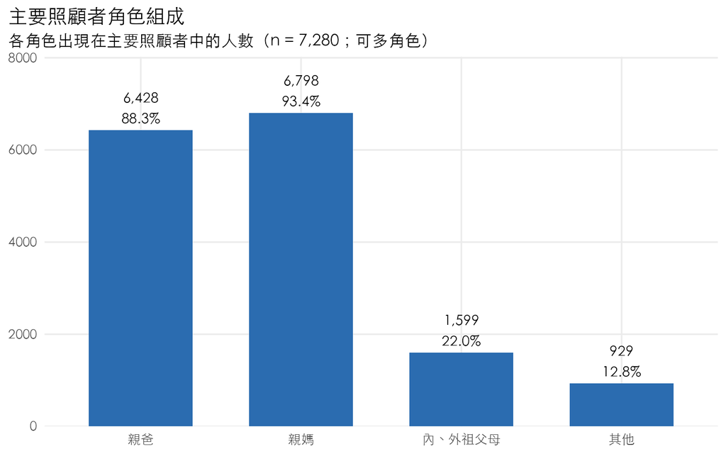

# 6 計分所用的變項與公式

步驟 1–3（§2–§5）回答了「**哪些學生**」與每位學生的「**主要照顧者是誰**」。接下來 步驟 4 要回答的是：**每位照顧者的教養，要怎麼量化成一個分數？** 本章先說明所用的題項 與複選題結構，再處理祖父母這個特殊單位，最後給出完整計分公式。

## 6.1 衡量要求與回應的 10 個題項

本研究嚴格依照小組成員陳仲毅同學的進度報告所列舉的變項計分。要求 （Demandingness）與回應（Responsiveness）各取 5 題，共 10 題：

| 維度 | 變項 | 題項（5/18 PDF 說明） | 原檔 Stata 標籤 |
| --- | --- | --- | --- |
| 要求 D | `w2s201` | 明確要求生活作息 | 要求生活作息 |
| 要求 D | `w2s202` | 嚴格管用錢 | 管用錢 |
| 要求 D | `w2s203` | 嚴格管功課 | 管功課 |
| 要求 D | `w2s204` | 要求言行舉止與服裝儀容 | 要求言行/服儀 |
| 要求 D | `w2s206` | 嚴格管交朋友 | 管交朋友 |
| 回應 R | `w2s212` | 願意聽你想法並溝通 | 認真聽想法/溝通 |
| 回應 R | `w2s214` | 經常關心與叮嚀 | 耳提面命 |
| 回應 R | `w2s217` | 願意答應需求 | 想要事物/答應 |
| 回應 R | `w2s218` | 遇到挫折時願意幫助你 | 挫折/撥空幫你 |
| 回應 R | `w2s219` | 很能接納你 | 接納你 |

## 6.2 複選題的子題結構

原檔中每一題（如 `w2s201`）其實是「**下列哪些人會對你『◯◯◯』**」的複選題，被拆成 數個 0／1 子題；**子題是按「個人性別」分的**（爸／媽／祖父／祖母／其他），與步驟 2 照顧者題的「父系／母系」維度不同。子題尾數對應如下：

| 子題尾數 | 對象 | 逐人加總欄位（要求 / 回應） |
| --- | --- | --- |
| 1 | 沒有人 | （不計分） |
| 2 | 爸爸 | `F_D` / `F_R` |
| 3 | 媽媽 | `M_D` / `M_R` |
| 4 | (外)祖父 | `GF_D` / `GF_R` |
| 5 | (外)祖母 | `GM_D` / `GM_R` |
| 6 | 家中其他人 | `O_D` / `O_R` |

每位照顧者的**要求分數** = 其在 5 道要求題的對應子題被勾選的題數加總（範圍 0–5）， **回應分數**同理。例：父親要求分數 `F_D` = `w2s2012 + w2s2022 + w2s2032 + w2s2042 + w2s2062`（尾數 2 = 爸爸）。特殊碼 99 與遺漏在加總時當 0。

## 6.3 照顧單位與祖父母的處理

D／R 分數的定義是「**各照顧者單位分數的平均**」。照顧單位有四種：親爸、親媽、 **祖父母（內、外合為一個單位）**、其他，**各占分母 1**。

祖父母為何合為「一個單位」：如步驟 2 所述，與誰住／誰照顧題對祖父母只有「夫妻對」 解析度，無法支撐「祖父、祖母各算一位照顧者」的拆法（硬拆會讓一對祖父母的權重等於 父母兩人加總）。因此在**問卷能分辨的粒度**上，祖父母就是一個照顧單位。

祖父母單位的分數，用教養題的性別欄位（`GF_*` 祖父、`GM_*` 祖母）來算，並先以教養題 核對個別祖父母是否「**涉入**」——**涉入定義 (a)**：在 10 題教養題中至少被勾選過 1 題。

| 祖父母涉入情形 | 祖父母單位分數 | 計入分母 |
| --- | --- | --- |
| 祖父、祖母都涉入 | (祖父分 ＋ 祖母分) ÷ 2 | 1 |
| 只有一位涉入 | 那一位的分數 | 1 |
| 兩位都沒涉入 | 0 | 1 |

祖父母單位只要在「住∪顧」聯集中，就**固定占分母 1**——即使兩位都零涉入、單位分數 為 0，仍算一位照顧者。這與「在主要照顧者中、但教養分數為 0 的父母」採同一套標準 （現行計分法對零參與的父母本來就是『占分母 1、貢獻 0 分』），祖父母不另設「丟棄」特例。

## 6.4 計分公式

設 $u_F, u_M, u_{GP}, u_O \in \{0,1\}$ 表示親爸、親媽、祖父母單位、其他是否為該生的 主要照顧者；$D_F, D_M, D_O$ 為各人在 5 題要求的加總（0–5），$D_{GP}$ 為祖父母單位 分數（依上表）。則

$$D\_score=\frac{u_F D_F + u_M D_M + u_{GP} D_{GP} + u_O
D_O}{n_{caregiver}},\qquad
n_{caregiver}=u_F+u_M+u_{GP}+u_O$$

回應分數 $R\_score$ 以相同公式、改用回應分數計算。

> **計分舉例**：某學生主要照顧者為親爸、親媽、內祖父母，兩位祖父母都涉入， `F_D = 4`、`M_D = 3`、祖父 `= 2`、祖母 `= 2`。祖父母單位 D ＝ (2 ＋ 2) ÷ 2 ＝ 2； 該生 `D_score` ＝ (4 ＋ 3 ＋ 2) ÷ 3 ＝ **3.0**。

# 7 祖父母涉入情形與邊界個案

祖父母是本研究計分最棘手的部分（§3 已說明住／顧題與教養題的維度落差）。本章把祖父母 相關的邊界個案、以及最容易被質疑的幾個設計選擇，集中講清楚。

最終樣本中，主要照顧者含祖父母者共 1,599 人。其中兩位祖父母**都沒涉入** （教養 10 題零勾選）者有 **631 人**。依 §6 規則，他們的祖父母單位分數記 0、 仍占分母 1——不額外排除，也不視為「極端忽視」資料點，而是當作「一個在本研究 10 個 D／R 題項上、觀察到的教養行為分數為 0 的照顧單位」。

兩個須在衡量限制中說明的特殊情形：

- **內、外祖父母都在主要照顧者中**者有 77 人。教養題的祖父／祖母欄是 內外混合（無內外軸），這些學生的祖父母只能併為一個單位、用性別欄計分。
- **反向案例**：教養題顯示祖父母有涉入、但祖父母不在主要照顧者聯集中者有 1,097 人。這些人的祖父母教養資料不納入計分（祖父母非其主要照顧者）。

## 7.1 預期讀者／助教會問的問題

祖父母「合為一個照顧單位」的設計選擇較多，這裡把最可能被追問的五個問題先回答：

**Q1：為什麼不把祖父母拆成「祖父」「祖母」兩位照顧者？** 因為決定「誰是主要照顧者」的住／顧題，對祖父母只有「夫妻對」解析度（內祖父母一格、 外祖父母一格），根本問不出「祖父是、祖母不是」這種個人層級的訊息。若硬拆成兩位，會讓 一對祖父母在分母占 2、權重等於父母兩人加總，計分並不公允。在**問卷能分辨的粒度**上， 祖父母就是一個照顧單位。

**Q2：主要照顧者同時有「內祖父母」和「外祖父母」怎麼辦？（77 人）** 教養 10 題的「祖父／祖母」欄位是按**性別**分、沒有內外軸——資料上根本無法把分數對應 回「內」或「外」。因此把所有祖父母（內、外）併為**一個單位**、用性別欄計分。這 不是任意決定，而是資料結構下唯一一致的做法。

**Q3：祖父母都沒涉入（10 題零勾選），為什麼還算一位照顧者、占分母 1？** 為了與父母一視同仁。現行計分法對「在主要照顧者中、但教養分數為 0 的父母」本來就是 「占分母 1、貢獻 0 分」。若把零涉入的祖父母「丟棄」、不計入分母，等於對祖父母和父母 採雙重標準。記 0 分、占分母 1，才是同一套規則。

**Q4：為什麼只對祖父母做「涉入」檢核，不對父母做？** 這正是補償 Q1 講的不對稱。住／顧題對父母是**逐人辨識**（爸、媽各一格），對祖父母只有 夫妻對。涉入檢核（用教養題反查祖父／祖母個人是否真的參與）是把祖父母拉到和父母相近的 解析度，**不是**對父母從寬、對祖父母從嚴。

**Q5：涉入為什麼定義成「至少勾 1 題」（定義 a），而不是「有被填答」（定義 b）？** 定義 b（10 題中至少一題為有效 0／1）只說明「這位祖父母的欄位有被作答」，連「完全沒 參與教養」都算「被填答」；定義 a（至少被勾選 1 題＝1）才真正反映「這位祖父母確實做了 某件教養的事」。本研究要的是後者，故採定義 a；定義 b 僅在腳本中作為診斷對照。

# 8 中位數切分與四類型

有了每位學生的 D、R 分數，最後一步（步驟 5）是把連續分數轉成 Maccoby & Martin 的四個 具名類型。把 7,280 人的 `D_score`、`R_score` 各自取中位數 （D 中位數 = 2、R 中位數 = 2.5），以**嚴格大於** 中位數為「高」。要求高低 × 回應高低交叉成 Maccoby & Martin 四類型：

**為什麼用樣本中位數切，而不是量尺理論中點（2.5）？** 中位數切分讓四類型的人數較均衡， 不會因為樣本整體偏低或偏高、使某一類幾乎空掉，這也是教養類型化研究的常見作法。代價是 切點隨樣本而定，且踩線者的歸類受「嚴格大於」規則影響——這個機械效應在 §9 與衡量限制 會再說明。要完全避開切分決策的，另有不切高低、直接用連續分數的迴歸分析（見《迴歸 分析》報告）。

四類教養方式的人數、占比與學業成就平均

| 教養類型 | 人數 | 占比 | w2all3p 平均 |
| --- | --- | --- | --- |
| 開明權威 | 1,808 | 24.8% | 0.883 |
| 專制權威 | 1,569 | 21.6% | 0.855 |
| 寬鬆放任 | 1,260 | 17.3% | 1.280 |
| 忽視冷漠 | 2,643 | 36.3% | 0.978 |

四類型的名稱沿用 Maccoby & Martin 的習慣譯名，但在本研究中是**操作型標籤**——例如 「忽視冷漠」僅指該生的 `D_score` 與 `R_score` **皆未高於中位數**，並不等於現實中這個 家庭真的冷漠或忽視孩子；其餘三類的命名亦同此理。

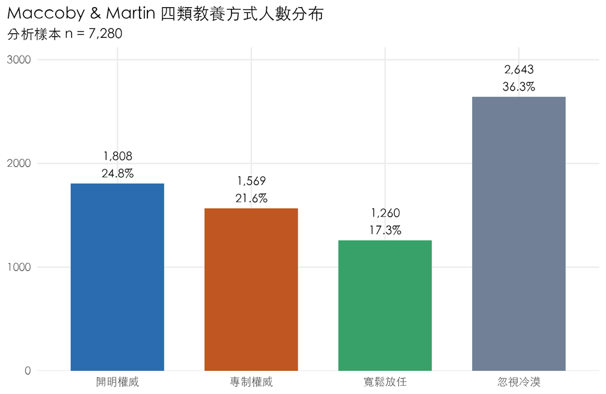

`D_score` 與 `R_score` 的分布如下。可以看到分數因「各照顧者分數平均」而呈離散的小數 階梯，中位數（紅虛線）也恰落在較規律的值上：

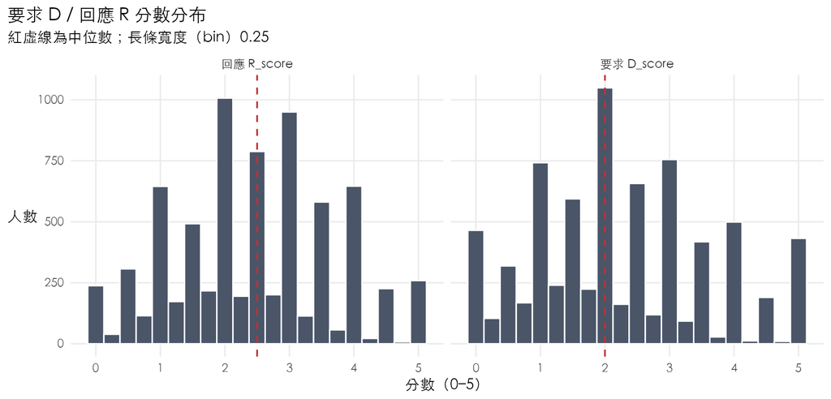

把每位學生畫在要求 × 回應平面上（泡泡大小為人數），四個象限即四類型。要強調的是， **分類完全依中位數**——D／R 嚴格大於各自的中位數為「高」，圖中虛線標示的就是這條 高低分界。由於分數離散、中位數恰落在某一排泡泡上，虛線若畫在中位數值會直接穿過那排 泡泡，因此改畫在「低組最高分與高組最低分之間」；位置雖與中位數值差一點，**切出的 高低兩組與中位數分類完全相同**，並與泡泡顏色的邊界對齊：

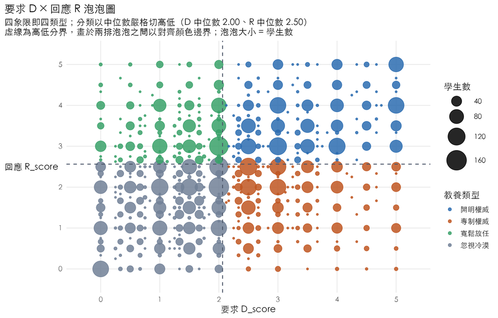

# 9 四類型與學業成就（描述性）

下表與下圖為各類型在三種 IRT 學業能力分數上的平均。**僅為描述性比較，未做檢定**。

**這三個成就指標怎麼來、怎麼算？** 它們出自 TEPS 的「**綜合分析能力測驗**」，並用 **3 參數 IRT 模型**把作答換算成能力分數。先把這兩個名詞解釋清楚：

> - **TEPS**（臺灣教育長期追蹤資料庫，Taiwan Education Panel Survey）：中央研究院主持的 大型教育長期追蹤調查，對同一批學生在不同年級重複施測與問卷；本研究用的是**第二波 （w2）國中學生**資料。每一波都施測一份「綜合分析能力測驗」，題目為推理題，分 **一般分析**（語文／邏輯推理）與**數學**兩個領域。
> - **3 參數 IRT（試題反應理論，3-PL）**：一種「**不直接用答對題數、改估潛在能力**」的 計分方法。它假設每位學生有一個看不見的能力值，某題答對與否由「學生能力」與「題目 特性」共同決定；每道題用三個參數刻畫——**難度**（要多高的能力才有一半機會答對）、 **鑑別度**（這題分辨高、低能力者的能力強不強）、**猜測度**（完全不會時、靠猜也可能 答對的機率，選擇題尤其要校正）。好處是：純答對題數會受「考了哪幾題、題目難易」影響、 不同題本之間不可比；IRT 把題目特性校正掉後，估出的能力分數才能**跨波次、跨學程 （國中／高中／高職／五專）公平比較**——這也是 TEPS 釋出這個分數的用意。

由此得到三個能力估計值：

| 指標 | 測的能力 | 來源題目 |
| --- | --- | --- |
| `w2all3p` **綜合分析能力** | 整體分析推理 | 全部測驗題 |
| `w2cf3p` **一般分析能力** | 語文／邏輯推理 | 一般分析題 |
| `w2m3p` **數學分析能力** | 數學推理 | 數學題 |

**為什麼主要看「綜合分析能力」（`w2all3p`）？** 綜合分數由全部題目估出、同時涵蓋一般與 數學兩個領域，是最能代表整體學習表現的單一指標；三個指標彼此又**高度相關** （r = 0.84–0.95），分開 看結論不會變。因此本報告**描述性**部分（下圖）三個並列呈現，後續**迴歸**則以綜合為主要 結果，並另以三個指標各跑一次交互模型做穩健性對照（見《迴歸分析》報告 §2.1，三者係數 方向一致）。

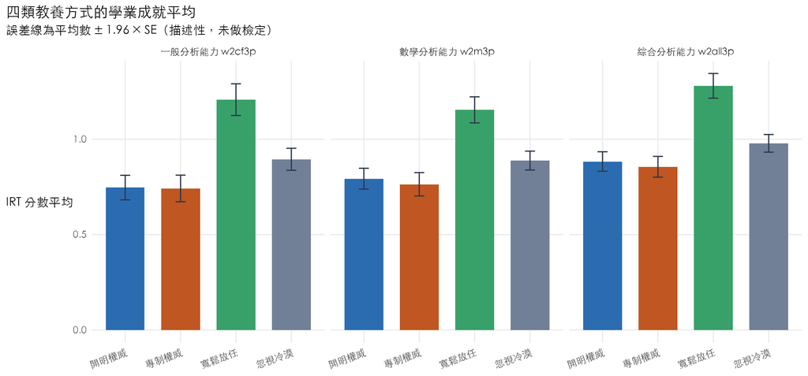

四類型的學業成就排序為 **寬鬆放任最高、專制權威最低**，與 Maccoby & Martin 西方理論 「開明權威最佳」的預期並不一致；這是本台灣樣本重建後仍可觀察到的描述性型態。可能的原因 （反向因果、題項內容偏向「父母管不管」、背景變項干擾等）須在後續分析與限制中審慎 討論，此處不下因果結論。

若不切高低、直接把學業成就畫在連續的 D × R 平面上（每格為格內 `w2all3p` 平均， 藍色高於全體平均、紅色低於），型態更清楚：

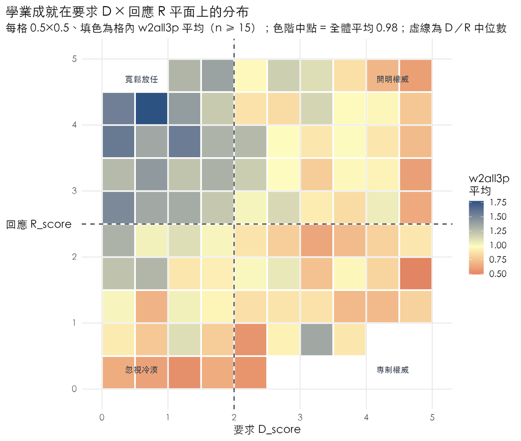

成就最高的格集中在**低要求、高回應**一側（寬鬆放任象限，圖左上呈藍色）；隨著要求 D 往右增加，格子普遍轉紅。也就是說，這個連續平面的主要梯度沿著**要求 D 軸**——圖面上 D 較高的區域、該格平均成就較低，此仍為未控制背景變項的描述性觀察；回應 R 的正向關聯 較溫和。此型態與上段「寬鬆放任最高、專制權威最低」 一致，且不受中位數切分影響。

「忽視冷漠」占比偏高（36.3%），與中位數 切分的機械效應有關：`D_score` 中位數恰落在整數值上、踩線者依「嚴格大於」規則全歸 「低」，加上前述 631 名「祖父母零涉入」者單位分數記 0，都會把樣本往低 D／ 低 R 推。

> **承上啟下。** 以上都是**描述性**觀察——看到了型態，但還沒有檢定。「寬鬆放任真的 顯著高於其他類嗎？」「要求 D 的負向關聯，在控制城鄉、公私立之後還在嗎？」這些問題 交給另一份《迴歸分析》報告（連續迴歸、分層檢定、四類型 ANOVA）回答。本報告到此 確立的，是一份**可信的分析資料**與幾個**重建後仍可觀察到的描述性型態**。

# 10 衡量限制

1. **時間落差**：照顧者題問的是「國小畢業前」，教養 10 題反映的較接近國中現況；兩題組 對「祖父母是否涉入教養」僅約 76% 一致。w2 學生檔無「現在與誰住」題，無法修正。
2. **內／外祖父母無法在計分中區分**：教養題祖父／祖母欄只有性別軸、無內外軸； 77 名內外祖父母都在主要照顧者中的學生，其祖父母只能併為一個單位計分。
3. **涉入檢核僅對祖父母施行**：這是補償問卷對祖父母只有「夫妻對」解析度（對父母則為 逐人辨識）的不對稱，並非對父母、祖父母採雙重標準。
4. **特殊碼 99 在加總時當 0**（每題約 0.5%，造成輕微低估）。
5. **中位數切分的機械效應**：離散分數加上「嚴格大於」規則，會把踩線者全歸「低」， 是「忽視冷漠」占比偏高的部分來源；解讀類型比例時須留意。
6. **照顧者題組與教養題組的對象未必完全一致**：少數學生兩題組互相矛盾（如主要照顧者 為祖父母、教養題卻大量勾父母），其分數會反映此一資料先天限制。
7. **現況才成為的同住／照顧者無法納入計分**：主要照顧者是依「國小畢業前」的住／顧題 認定的；若某位長輩是在那之後才與學生同住或開始照顧，問卷無法將其辨識為主要照顧者， 其管教行為即使反映在較接近現況的 10 個教養題項中，也無從對應、納入 D／R 計分。此點 與第 1 點的時間落差同源，但影響的是計分「涵蓋了哪些照顧者」。

# 11 附錄：完整程式碼

以下為三支腳本的完整內容（含註解）。程式碼即此報告正文結果與圖的唯一來源；本報告於 設定階段直接 `source()` 這三支腳本後再計算正文數字，因此報告與腳本必然一致。

## 11.1 附錄 A：`rebuild_caregiver.R`（步驟 1–3）

```r
# =============================================================================
# 從 TEPS 第二波學生原始檔，建立每位學生的「主要照顧者」——聯集法（同住 ∪ 照顧）
# -----------------------------------------------------------------------------
# 資料來源：Data/stata/w2_j_s_v6.0.dta（TEPS 第二波學生問卷原始檔）。
#
# 推論規則（與小組討論定案）：
#   步驟 1  品質旗標：w2refuse / w2sumerr / w2sumlog 三者皆 0 才保留。
#   步驟 2  主要照顧者 = 逐角色「同住 ∪ 照顧」聯集（w2s456x ∪ w2s457x）。
#   步驟 3  排除繼父母進聯集者；排除無任何親屬者（「只有其他」/ 無人）。
#
# 註：本檔以「# ---- 英數標籤 ----」標記區段，方便閱讀與對應報告章節；程式碼可由
#     報告 .Rmd 以 source() 呼叫，也可直接以 Rscript 執行（須在專案根目錄下）。
# =============================================================================

# ---- setup ----
# 套件與輸出資料夾。工作目錄須為專案根目錄（含 Data/ 與 教養分析/）：
# 由報告 .Rmd 以 source() 呼叫時已設定好；單獨執行請先 setwd() 到專案根目錄。
library(haven)
out_dir <- file.path("教養分析", "outputs", "caregiver_rebuild")
dir.create(out_dir, recursive = TRUE, showWarnings = FALSE)

# ---- read-raw ----
# 讀入 TEPS w2 學生原始檔。haven 讀進來是 labelled 欄位，全部轉成數值碼，
# 之後一律以數值比較（== 1、== 0、== 99）。
d <- as.data.frame(read_dta("Data/stata/w2_j_s_v6.0.dta", encoding = "BIG5"))
for (v in names(d)) d[[v]] <- as.numeric(d[[v]])
N0 <- nrow(d)

# ---- quality-flags ----
# 步驟 1：問卷自帶的三個品質旗標，必須同時為 0（無拒答、零不合理值、零邏輯衝突）
# 才保留。is1() 是「值等於 1 且非 NA」的小工具，後面判斷勾選都用它。
is1 <- function(x) !is.na(x) & x == 1
qpass <- d$w2refuse == 0 & d$w2sumerr == 0 & d$w2sumlog == 0

# ---- union-caregiver ----
# 步驟 2：逐角色取「同住題(w2s456x) ∪ 照顧題(w2s457x)」聯集。
# 住 / 顧題對祖父母只到「夫妻對」層級：內祖父母(G) = 父系一對、外祖父母(MG) = 母系一對。
u_F  <- is1(d$w2s4561) | is1(d$w2s4571)   # 親爸
u_M  <- is1(d$w2s4562) | is1(d$w2s4572)   # 親媽
u_GF <- is1(d$w2s4563) | is1(d$w2s4573)   # 內祖父母（父系，一對）
u_GM <- is1(d$w2s4564) | is1(d$w2s4574)   # 外祖父母（母系，一對）
u_S  <- is1(d$w2s4565) | is1(d$w2s4575)   # 養繼父母
u_O  <- is1(d$w2s4566) | is1(d$w2s4576)   # 其他
has_kin <- u_F | u_M | u_GF | u_GM        # 是否至少有一位「親屬」照顧者

# ---- exclusion ----
# 步驟 3：繼父母進入聯集者整案排除（單從問卷無法得知實際教養情形）；
# 無任何親屬者（只有「其他」或無人）排除。keep 即最終分析樣本旗標。
keep <- qpass & !u_S & has_kin

# ---- caregiver-string ----
# main_caregiver 字串、代碼、人數。token：F 親爸 / M 親媽 / G 內祖 / MG 外祖 / O 其他。
# 注意 n_caregiver 此處把內、外祖父母各算 1；「祖父母內外合為一單位」的合併在
# dr_scoring.R 重算，不在這裡。
tokens <- cbind(
  ifelse(u_F,  "F",  ""), ifelse(u_M,  "M",  ""), ifelse(u_GF, "G",  ""),
  ifelse(u_GM, "MG", ""), ifelse(u_O,  "O",  "")
)
main_caregiver <- apply(tokens, 1, function(r) paste(r[r != ""], collapse = "+"))
n_caregiver    <- u_F + u_M + u_GF + u_GM + u_O          # 繼父母案已排除，不計
caregiver_code <- u_F * 1 + u_M * 2 + u_GF * 4 + u_GM * 8 + u_O * 16

# ---- gp-involvement ----
# 祖父 / 祖母「涉入」診斷，供 dr_scoring.R 的祖父母計分規則使用。
# 教養 10 題的子題：(外)祖父 = 子題 4、(外)祖母 = 子題 5。
gf_items <- c("w2s2014","w2s2024","w2s2034","w2s2044","w2s2064",
              "w2s2124","w2s2144","w2s2174","w2s2184","w2s2194")
gm_items <- c("w2s2015","w2s2025","w2s2035","w2s2045","w2s2065",
              "w2s2125","w2s2145","w2s2175","w2s2185","w2s2195")
GF <- d[, gf_items]; GM <- d[, gm_items]
# 定義(b)：被填答 = 至少一題為有效 0/1（特殊碼 99 不算）。僅供診斷對照。
gf_answered <- rowSums(GF == 0 | GF == 1, na.rm = TRUE) > 0
gm_answered <- rowSums(GM == 0 | GM == 1, na.rm = TRUE) > 0
# 定義(a)：涉入 = 至少一題被勾選 (=1)。〔正式分析採用此定義〕
gf_involved <- rowSums(GF == 1, na.rm = TRUE) > 0
gm_involved <- rowSums(GM == 1, na.rm = TRUE) > 0

# ---- write-output ----
# 輸出重建後的照顧者表（全 13,247 列，附 keep 旗標供下游過濾）。
rebuilt <- data.frame(
  stud_id = d$stud_id,
  w2refuse = d$w2refuse, w2sumerr = d$w2sumerr, w2sumlog = d$w2sumlog,
  qpass = qpass,
  u_F = as.integer(u_F), u_M = as.integer(u_M), u_GF = as.integer(u_GF),
  u_GM = as.integer(u_GM), u_S = as.integer(u_S), u_O = as.integer(u_O),
  has_kin = has_kin, keep = keep,
  main_caregiver = main_caregiver, caregiver_code = caregiver_code,
  n_caregiver = n_caregiver,
  gf_answered = gf_answered, gm_answered = gm_answered,
  gf_involved = gf_involved, gm_involved = gm_involved
)
write.csv(rebuilt, file.path(out_dir, "caregiver_rebuilt.csv"),
          row.names = FALSE, fileEncoding = "UTF-8")

# ---- report-funnel ----
# 樣本 funnel：原始 → 品質旗標 → 排除繼父母 → 排除無親屬。
cat("\n========== 樣本 funnel ==========\n")
n_q   <- sum(qpass)
n_s   <- sum(qpass & u_S)
n_nok <- sum(qpass & !u_S & !has_kin)
n_fin <- sum(keep)
cat(sprintf("  原始樣本                         : %5d\n", N0))
cat(sprintf("  步驟1 品質旗標皆為 0              : %5d  (排除 %d)\n", n_q, N0 - n_q))
cat(sprintf("  步驟3a 排除「繼父母進聯集」        : %5d  (排除 %d)\n", n_q - n_s, n_s))
cat(sprintf("  步驟3b 排除「無親屬／只有其他」    : %5d  (排除 %d)\n", n_fin, n_nok))
cat(sprintf("  ── 聯集法最終樣本                 : %5d\n", n_fin))

# ---- report-composition ----
# 主要照顧者組成：人數分布、前 12 大組合、各角色出現人數。
cat("\n========== 主要照顧者人數分布（最終樣本）==========\n")
print(table(n_caregiver[keep]))

cat("\n========== 前 12 大主要照顧者組合 ==========\n")
tt <- sort(table(main_caregiver[keep]), decreasing = TRUE)
print(head(tt, 12))

cat("\n========== 各角色出現在主要照顧者中的人數 ==========\n")
cat(sprintf("  親爸 F  : %d\n", sum(u_F[keep])))
cat(sprintf("  親媽 M  : %d\n", sum(u_M[keep])))
cat(sprintf("  內祖 G  : %d\n", sum(u_GF[keep])))
cat(sprintf("  外祖 MG : %d\n", sum(u_GM[keep])))
cat(sprintf("  其他 O  : %d\n", sum(u_O[keep])))
grandU <- (u_GF | u_GM)
cat(sprintf("  含祖父母（內或外）: %d\n", sum(keep & grandU)))

# ---- report-edgecase ----
# 祖父母邊界個案診斷：對照定義(b) 與定義(a) 下「祖父母進聯集但零涉入」的人數。
cat("\n========== 祖父母邊界個案診斷 ==========\n")
sub <- keep & grandU
cat(sprintf("最終樣本中「祖父母進聯集」的學生：%d 人\n\n", sum(sub)))
cat("定義(b) 被填答 = 至少一題有效作答(0/1)；從沒被填答 = 10題全99\n")
print(table(祖父 = ifelse(gf_answered[sub], "被填答", "全99"),
            祖母 = ifelse(gm_answered[sub], "被填答", "全99")))
cat(sprintf("  -> 邊界個案（兩者皆從沒被填答）：%d 人\n\n",
            sum(!gf_answered[sub] & !gm_answered[sub])))
cat("定義(a) 涉入 = 至少一題被勾選(=1)；沒涉入 = 10題都沒被勾\n")
print(table(祖父 = ifelse(gf_involved[sub], "有涉入", "沒涉入"),
            祖母 = ifelse(gm_involved[sub], "有涉入", "沒涉入")))
edge_a <- sub & !gf_involved & !gm_involved
cat(sprintf("  -> 邊界個案（兩者皆沒涉入）：%d 人\n", sum(edge_a)))
# 邊界個案中，祖父母是否為「唯一」照顧者（無父母）。
gp_only <- edge_a & !u_F & !u_M
cat(sprintf("     其中祖父母為唯一照顧者（無父母同列）：%d 人\n", sum(gp_only)))

cat("\n已輸出：", normalizePath(file.path(out_dir, "caregiver_rebuilt.csv")), "\n")
```

## 11.2 附錄 B：`dr_scoring.R`（步驟 4–5）

```r
# =============================================================================
# Phase 2：D / R 計分與四類型（祖父母內、外合為一個照顧單位）
# -----------------------------------------------------------------------------
# 前置：rebuild_caregiver.R 已產出 caregiver_rebuilt.csv。
#
# 計分規則（與小組討論定案）：
#   照顧單位：親爸、親媽、祖父母（內 + 外合為「一個」單位）、其他，各占分母 1。
#   每位照顧者的 D / R 分數 = 其在 5 題要求 / 5 題回應的勾選加總（特殊碼 99 當 0）。
#   祖父母單位分數 = 有「涉入」之祖父母的平均（涉入 = 10 題中至少 1 題被勾選）：
#       祖父、祖母都涉入 → (祖父 + 祖母) / 2
#       只有一位涉入     → 那一位
#       兩位都沒涉入     → 0 分
#   祖父母單位只要在「住∪顧」中就固定占分母 1（零涉入也算 1 位、貢獻 0 分），
#   與「在主要照顧者中、但教養分數為 0 的父母」同等對待。
#   D_score = Σ(各單位分數) / n_caregiver；中位數切分（嚴格 >）分四型。
#
# 註：本檔以「# ---- 英數標籤 ----」標記區段，方便閱讀與對應報告章節；程式碼可由
#     報告 .Rmd 以 source() 呼叫，也可直接以 Rscript 執行（須在專案根目錄下）。
# =============================================================================

# ---- setup ----
# 套件與輸出資料夾。工作目錄須為專案根目錄（含 Data/ 與 教養分析/）：
# 由報告 .Rmd 以 source() 呼叫時已設定好；單獨執行請先 setwd() 到專案根目錄。
library(haven)
base    <- "教養分析"
out_dir <- file.path(base, "outputs", "dr_scoring")
dir.create(out_dir, recursive = TRUE, showWarnings = FALSE)

# ---- read-align ----
# 讀入 rebuild_caregiver.R 的照顧者表 (cg) 與原始問卷檔 (d)，
# 並把 d 依 cg 的 stud_id 順序對齊，之後所有運算逐列對應。
cg <- read.csv(file.path(base, "outputs", "caregiver_rebuild", "caregiver_rebuilt.csv"),
               fileEncoding = "UTF-8")
d  <- as.data.frame(read_dta("Data/stata/w2_j_s_v6.0.dta", encoding = "BIG5"))
for (v in names(d)) d[[v]] <- as.numeric(d[[v]])

# 防呆：對齊前先確認 stud_id 能當唯一鍵、且每筆 cg 都在原檔找得到對應。
# 萬一資料對不齊，這裡會直接報錯中止，不會靜默產出錯誤結果。
stopifnot(
  "cg$stud_id 有重複"          = anyDuplicated(cg$stud_id) == 0,
  "原檔 stud_id 有重複"        = anyDuplicated(d$stud_id)  == 0,
  "有 cg$stud_id 在原檔找不到" = all(!is.na(match(cg$stud_id, d$stud_id)))
)
d <- d[match(cg$stud_id, d$stud_id), ]
# 對齊後再逐列確認 stud_id 完全相等——往後所有 cg／d 的逐列運算才成立。
stopifnot("對齊後 stud_id 未完全一致" = all(d$stud_id == cg$stud_id))

# ---- parenting-sums ----
# 逐人教養加總。每題子題：2=爸 3=媽 4=(外)祖父 5=(外)祖母 6=家中其他人。
# clean01() 把特殊碼 99 / NA 當 0；psum() 對某子題、跨指定題目加總。
clean01 <- function(x) ifelse(!is.na(x) & x %in% c(0, 1), x, 0)
D_items <- c("201", "202", "203", "204", "206")   # 要求 (Demandingness)
R_items <- c("212", "214", "217", "218", "219")   # 回應 (Responsiveness)
psum <- function(items, sub) rowSums(sapply(d[paste0("w2s", items, sub)], clean01))
F_D  <- psum(D_items, 2); M_D  <- psum(D_items, 3); GF_D <- psum(D_items, 4)
GM_D <- psum(D_items, 5); O_D  <- psum(D_items, 6)
F_R  <- psum(R_items, 2); M_R  <- psum(R_items, 3); GF_R <- psum(R_items, 4)
GM_R <- psum(R_items, 5); O_R  <- psum(R_items, 6)

# ---- gp-unit ----
# 祖父母單位分數：有涉入之祖父母的平均；都沒涉入 → 0。
# gp_in：祖父母單位是否存在（內或外任一進聯集）。gfi / gmi：祖父 / 祖母是否涉入。
gp_in <- (cg$u_GF == 1 | cg$u_GM == 1)
gfi   <- cg$gf_involved
gmi   <- cg$gm_involved
unit_D <- ifelse(gfi & gmi, (GF_D + GM_D) / 2,
          ifelse(gfi & !gmi, GF_D,
          ifelse(!gfi & gmi, GM_D, 0)))
unit_R <- ifelse(gfi & gmi, (GF_R + GM_R) / 2,
          ifelse(gfi & !gmi, GF_R,
          ifelse(!gfi & gmi, GM_R, 0)))

# ---- dr-score ----
# n_caregiver（祖父母內外整體算 1）與 D / R score。
# 祖父母單位只要存在就占分母 1（gp），分子放單位分數（零涉入時 unit_* = 0）。
gp <- as.integer(gp_in)
n_caregiver <- cg$u_F + cg$u_M + gp + cg$u_O
D_score <- (cg$u_F * F_D + cg$u_M * M_D + gp * unit_D + cg$u_O * O_D) / n_caregiver
R_score <- (cg$u_F * F_R + cg$u_M * M_R + gp * unit_R + cg$u_O * O_R) / n_caregiver

# ---- analysis-frame ----
# 組成分析資料框，只留最終樣本 (keep)。同時保留各單位分數，方便日後核對 / 除錯。
keep <- cg$keep
ana <- data.frame(
  stud_id = cg$stud_id,
  main_caregiver = cg$main_caregiver,
  u_F = cg$u_F, u_M = cg$u_M, u_GF = cg$u_GF, u_GM = cg$u_GM, u_O = cg$u_O,
  gf_involved = cg$gf_involved, gm_involved = cg$gm_involved,
  n_caregiver = n_caregiver,
  F_D = F_D, M_D = M_D, GF_D = GF_D, GM_D = GM_D, O_D = O_D, unit_D = unit_D,
  F_R = F_R, M_R = M_R, GF_R = GF_R, GM_R = GM_R, O_R = O_R, unit_R = unit_R,
  D_score = D_score, R_score = R_score,
  w2all3p = d$w2all3p, w2m3p = d$w2m3p, w2cf3p = d$w2cf3p,
  w2stwt1 = d$w2stwt1, w2stwt2 = d$w2stwt2,
  w2far = d$w2far, w2priv = d$w2priv, w2urban3 = d$w2urban3,
  w2s445 = d$w2s445   # 性別：1 男、2 女
)[keep, ]

# ---- median-split ----
# 中位數切分（嚴格 >）→ Maccoby & Martin 四類型。
D_med <- median(ana$D_score)
R_med <- median(ana$R_score)
ana$D_type <- ifelse(ana$D_score > D_med, "高要求", "低要求")
ana$R_type <- ifelse(ana$R_score > R_med, "高回應", "低回應")
ana$Type <- factor(
  ifelse(ana$D_type == "高要求" & ana$R_type == "高回應", "開明權威",
  ifelse(ana$D_type == "高要求" & ana$R_type == "低回應", "專制權威",
  ifelse(ana$D_type == "低要求" & ana$R_type == "高回應", "寬鬆放任", "忽視冷漠"))),
  levels = c("開明權威", "專制權威", "寬鬆放任", "忽視冷漠")
)

# ---- write-output ----
# 輸出最終分析資料（CSV 供檢視、RDS 供下游報告快速讀取）。
write.csv(ana, file.path(out_dir, "analysis_data.csv"),
          row.names = FALSE, fileEncoding = "UTF-8")
saveRDS(list(data = ana, D_med = D_med, R_med = R_med),
        file.path(out_dir, "analysis_data.rds"))

# ---- report-scores ----
# 主控台報告（一）：樣本數、n_caregiver 分布、D / R score 摘要。
cat("\n========== 最終分析樣本 ==========\n")
cat(sprintf("  n = %d\n", nrow(ana)))

cat("\n========== n_caregiver 分布（祖父母內外整體算 1）==========\n")
print(table(ana$n_caregiver))

cat("\n========== D_score / R_score ==========\n")
cat(sprintf("  D_score：中位數 %.3f，平均 %.3f，範圍 [%.2f, %.2f]\n",
            D_med, mean(ana$D_score), min(ana$D_score), max(ana$D_score)))
cat(sprintf("  R_score：中位數 %.3f，平均 %.3f，範圍 [%.2f, %.2f]\n",
            R_med, mean(ana$R_score), min(ana$R_score), max(ana$R_score)))

# ---- report-types ----
# 主控台報告（二）：四類型分布、四類型 × 學業成就 w2all3p。
cat("\n========== 四類型分布 ==========\n")
tt <- table(ana$Type)
for (i in seq_along(tt))
  cat(sprintf("  %-8s %5d  (%.1f%%)\n", names(tt)[i], tt[i], 100 * tt[i] / sum(tt)))

cat("\n========== 四類型 × 學業成就 w2all3p ==========\n")
for (lv in levels(ana$Type)) {
  s <- ana$w2all3p[ana$Type == lv]
  cat(sprintf("  %-8s n=%5d  平均 %.3f  (SD %.3f)\n",
              lv, sum(!is.na(s)), mean(s, na.rm = TRUE), sd(s, na.rm = TRUE)))
}

cat("\n已輸出：", normalizePath(file.path(out_dir, "analysis_data.csv")), "\n")
```

## 11.3 附錄 C：`visualize.R`（視覺化）

```r
# =============================================================================
# Phase 3：視覺化
# -----------------------------------------------------------------------------
# 讀 dr_scoring.R 產出的 analysis_data.rds，產生四類型 / D×R / 學業成就等圖。
# 字型 Heiti TC + ragg::agg_png——macOS 上才能讓中文不變成空白方塊。
#
# 註：本檔以「# ---- 英數標籤 ----」標記區段，與其他腳本一致。
# =============================================================================

# ---- setup ----
library(ggplot2)
library(dplyr)
library(tidyr)
library(scales)

# 工作目錄須為專案根目錄（含 Data/ 與 教養分析/）：由報告 .Rmd 以 source()
# 呼叫時已設定好；單獨執行請先 setwd() 到專案根目錄。
base    <- "教養分析"
out_dir <- file.path(base, "outputs", "figures")
dir.create(out_dir, recursive = TRUE, showWarnings = FALSE)

obj   <- readRDS(file.path(base, "outputs", "dr_scoring", "analysis_data.rds"))
ana   <- obj$data
D_med <- obj$D_med
R_med <- obj$R_med

# ---- theme ----
# 共用字型、繪圖裝置與主題；新圖一律沿用，確保風格一致。
font_family <- "Heiti TC"
png_device  <- if (requireNamespace("ragg", quietly = TRUE)) ragg::agg_png else "png"
theme_set(theme_minimal(base_size = 13, base_family = font_family) +
  theme(plot.title.position = "plot",
        panel.grid.minor = element_blank(),
        axis.title.y = element_blank()))

type_levels <- c("開明權威", "專制權威", "寬鬆放任", "忽視冷漠")
type_colors <- c("開明權威" = "#2B6CB0", "專制權威" = "#C05621",
                 "寬鬆放任" = "#38A169", "忽視冷漠" = "#718096")

save_plot <- function(p, file, w = 9, h = 5.5)
  ggsave(file.path(out_dir, file), p, width = w, height = h, dpi = 180,
         device = png_device, bg = "white")

# 泡泡圖虛線的繪製位置：低組最大值與高組最小值的中點。分類本身仍以「D／R 嚴格大於
# 中位數」為準，此處只是讓虛線落在兩排離散泡泡「之間」、與顏色邊界對齊（直接畫在中位數
# 會穿過一排泡泡、且與顏色邊界錯開）；切出的高低兩組與中位數切分完全相同。
D_cut <- (max(ana$D_score[ana$D_score <= D_med]) +
          min(ana$D_score[ana$D_score >  D_med])) / 2
R_cut <- (max(ana$R_score[ana$R_score <= R_med]) +
          min(ana$R_score[ana$R_score >  R_med])) / 2

# ---- fig1-type-counts ----
# 圖 1：四類教養方式人數分布。
tc <- ana %>% count(Type) %>% mutate(pct = n / sum(n))
p1 <- ggplot(tc, aes(Type, n, fill = Type)) +
  geom_col(width = 0.7) +
  geom_text(aes(label = sprintf("%s\n%.1f%%", comma(n), 100 * pct)),
            vjust = -0.2, family = font_family, size = 4) +
  scale_fill_manual(values = type_colors, guide = "none") +
  scale_y_continuous(expand = expansion(mult = c(0, 0.18))) +
  labs(title = "Maccoby & Martin 四類教養方式人數分布",
       subtitle = sprintf("分析樣本 n = %s", comma(nrow(ana))),
       x = NULL, y = "人數")
save_plot(p1, "01_type_counts.png", 8, 5.2)

# ---- fig2-dr-bubble ----
# 圖 2：要求 D × 回應 R 泡泡圖。離散分數用 geom_count 疊成泡泡，避免 jitter 的視覺假象。
# 分類以中位數為準；虛線畫在 D_cut／R_cut（見上）只是繪圖位置，標示的仍是中位數高低分界。
p2 <- ggplot(ana, aes(D_score, R_score, color = Type)) +
  geom_count(alpha = 0.85) +
  scale_size_area(max_size = 13, name = "學生數") +
  scale_color_manual(values = type_colors, name = "教養類型") +
  geom_vline(xintercept = D_cut, linetype = "dashed", color = "#4A5568") +
  geom_hline(yintercept = R_cut, linetype = "dashed", color = "#4A5568") +
  scale_x_continuous(breaks = 0:5, limits = c(-0.3, 5.3)) +
  scale_y_continuous(breaks = 0:5, limits = c(-0.3, 5.3)) +
  labs(title = "要求 D × 回應 R 泡泡圖",
       subtitle = sprintf("四象限即四類型；分類以中位數嚴格切高低（D 中位數 %.2f、R 中位數 %.2f）\n虛線為高低分界，畫於兩排泡泡之間以對齊顏色邊界；泡泡大小 = 學生數",
                          D_med, R_med),
       x = "要求 D_score", y = "回應 R_score") +
  theme(axis.title.y = element_text(), legend.position = "right")
save_plot(p2, "02_DR_bubble.png", 10, 6.4)

# ---- fig3-achievement ----
# 圖 3：四類型 × 三種學業成就（IRT 分數）平均，誤差線為 95% CI。
achv <- ana %>%
  select(Type, w2all3p, w2m3p, w2cf3p) %>%
  pivot_longer(-Type, names_to = "outcome", values_to = "score") %>%
  filter(!is.na(score)) %>%
  mutate(outcome = recode(outcome,
    w2all3p = "綜合分析能力 w2all3p",
    w2m3p   = "數學分析能力 w2m3p",
    w2cf3p  = "一般分析能力 w2cf3p")) %>%
  group_by(outcome, Type) %>%
  summarise(n = n(), mean = mean(score), se = sd(score) / sqrt(n()), .groups = "drop")
p3 <- ggplot(achv, aes(Type, mean, fill = Type)) +
  geom_col(width = 0.7) +
  geom_errorbar(aes(ymin = mean - 1.96 * se, ymax = mean + 1.96 * se),
                width = 0.18, color = "#2D3748") +
  facet_wrap(~outcome, ncol = 3) +
  scale_fill_manual(values = type_colors, guide = "none") +
  labs(title = "四類教養方式的學業成就平均",
       subtitle = "誤差線為平均數 ± 1.96 × SE（描述性，未做檢定）",
       x = NULL, y = "IRT 分數平均") +
  theme(axis.text.x = element_text(angle = 20, hjust = 1),
        axis.title.y = element_text())
save_plot(p3, "03_achievement_by_type.png", 12, 5.6)

# ---- fig4-dr-distribution ----
# 圖 4：要求 D / 回應 R 分數分布；紅虛線為中位數切點。
sl <- ana %>%
  select(D_score, R_score) %>%
  pivot_longer(everything(), names_to = "dim", values_to = "score") %>%
  mutate(dim = recode(dim, D_score = "要求 D_score", R_score = "回應 R_score"))
meds <- data.frame(dim = c("要求 D_score", "回應 R_score"), m = c(D_med, R_med))
p4 <- ggplot(sl, aes(score)) +
  geom_histogram(binwidth = 0.25, fill = "#4A5568", color = "white") +
  geom_vline(data = meds, aes(xintercept = m), color = "#C53030",
             linetype = "dashed", linewidth = 0.7) +
  facet_wrap(~dim) +
  labs(title = "要求 D / 回應 R 分數分布",
       subtitle = "紅虛線為中位數；長條寬度（bin）0.25",
       x = "分數（0–5）", y = "人數") +
  theme(axis.title.y = element_text())
save_plot(p4, "04_DR_distribution.png", 10, 4.8)

# ---- fig5-caregiver-roles ----
# 圖 5：主要照顧者角色組成（同一學生可同時屬於多角色）。
roles <- data.frame(
  角色 = factor(c("親爸", "親媽", "內、外祖父母", "其他"),
               levels = c("親爸", "親媽", "內、外祖父母", "其他")),
  n = c(sum(ana$u_F), sum(ana$u_M),
        sum(ana$u_GF == 1 | ana$u_GM == 1), sum(ana$u_O)))
roles$pct <- roles$n / nrow(ana)
p5 <- ggplot(roles, aes(角色, n)) +
  geom_col(width = 0.65, fill = "#2B6CB0") +
  geom_text(aes(label = sprintf("%s\n%.1f%%", comma(n), 100 * pct)),
            vjust = -0.2, family = font_family, size = 4) +
  scale_y_continuous(expand = expansion(mult = c(0, 0.18))) +
  labs(title = "主要照顧者角色組成",
       subtitle = sprintf("各角色出現在主要照顧者中的人數（n = %s；可多角色）",
                          comma(nrow(ana))),
       x = NULL, y = "人數")
save_plot(p5, "05_caregiver_roles.png", 8, 5)

# ---- fig6-achievement-heatmap ----
# 圖 6：學業成就 w2all3p 在要求 D × 回應 R 連續平面上的熱圖。
# 每格 0.5×0.5，填色為格內平均；僅顯示 n ≥ 15 的格以免單點雜訊。
# 虛線用 D／R 中位數本身（非泡泡圖的視覺切點 D_cut／R_cut）——熱圖格邊落在 0.5 的
# 整數倍上，中位數恰在格邊、與格線對齊；視覺切點落在 2.x 反而會切穿格子。
bw <- 0.5
overall_achv <- mean(ana$w2all3p, na.rm = TRUE)
hm <- ana %>%
  filter(!is.na(w2all3p)) %>%
  mutate(Dbin = (pmin(floor(D_score / bw), 5 / bw - 1) + 0.5) * bw,
         Rbin = (pmin(floor(R_score / bw), 5 / bw - 1) + 0.5) * bw) %>%
  group_by(Dbin, Rbin) %>%
  summarise(mean_achv = mean(w2all3p), n = n(), .groups = "drop") %>%
  filter(n >= 15)
quad <- data.frame(x = c(4.4, 4.4, 0.6, 0.6), y = c(4.7, 0.3, 4.7, 0.3),
                   lab = c("開明權威", "專制權威", "寬鬆放任", "忽視冷漠"))
p6 <- ggplot(hm, aes(Dbin, Rbin, fill = mean_achv)) +
  geom_tile(width = bw * 0.95, height = bw * 0.95) +
  scale_fill_gradient2(low = "#C53030", mid = "#FEFCBF", high = "#2C5282",
                       midpoint = overall_achv, name = "w2all3p\n平均") +
  geom_vline(xintercept = D_med, linetype = "dashed", color = "#2D3748") +
  geom_hline(yintercept = R_med, linetype = "dashed", color = "#2D3748") +
  annotate("text", x = quad$x, y = quad$y, label = quad$lab,
           family = font_family, size = 3.4, color = "#2D3748", fontface = "bold") +
  coord_fixed() +
  scale_x_continuous(breaks = 0:5, limits = c(-0.05, 5.05)) +
  scale_y_continuous(breaks = 0:5, limits = c(-0.05, 5.05)) +
  labs(title = "學業成就在要求 D × 回應 R 平面上的分布",
       subtitle = sprintf("每格 %.1f×%.1f、填色為格內 w2all3p 平均（n ≥ 15）；色階中點 = 全體平均 %.2f；虛線為 D／R 中位數",
                          bw, bw, overall_achv),
       x = "要求 D_score", y = "回應 R_score") +
  theme(axis.title.y = element_text())
save_plot(p6, "06_achievement_heatmap.png", 8.5, 7.2)

message("已輸出 6 張圖至 ", normalizePath(out_dir))
```